# Model training

David Neuzerling

2019-12-11

This package exists to explore the concept of creating a machine learning model as an R package, similar to the established concept of an analysis as an R package. The idea here is that, using vignettes, we can train the model by installing the package. The functions in the package then allow the user to score new data with the trained model. To demonstrate this I’ve created an extremely simple sentiment analysis model based on [review data from the UCI Machine Learning Repository](https://archive.ics.uci.edu/ml/datasets/Sentiment+Labelled+Sentences).

I thought this might work because of a few things:

- Vignettes are created before the source code is bundled, so in theory we can train a model before the package has finished compiling.
- R uses lazy evaluation, so if a package function refers to an object that doesn’t yet exist (because it hasn’t been created by the vignette) that’s okay.
- I like using the same functions for model training as I do for model scoring, like the `map_to_dtm` function in this package.
- I wanted to take full advantage of `roxygen2` for documenting package functions, and `testthat` for unit tests. I especially like the ease with which you can test within RStudio.

However, I have my doubts:

- In order for tests to work, I have to run `devtools::build_vignettes` before running `devtools::install`. There’s something here with namespaces whereby the data objects suddenly become “unexported” after tests are attempted. I don’t know why!
- There are some relative paths in the code. I’m assuming that the working directory is `<package_root>/vignettes` when this vignette is knitted, so I can move up one level to obtain the root directory of the package. This should be okay if we’re following the standard package structure, but I’ve been hurt too many times by relative file paths to feel comfortable about this.
- I’m not sure how this would operate with the `plumber` package. I don’t know if we can integrate the expected `plumber.R` file in the package, except for sticking it in the `inst` directory and then finding it with `system.file`.
- This all seems like a lot of complexity for not too much benefit. Maybe doing this again would be easier now that I have a template.

No matter what, I think these sorts of projects have to be shared, even if I don’t think that this is a major success!

A quick shout out for [the excellent book on R packages by Hadley Wickham](http://r-pkgs.had.co.nz/). It’s well worth keeping bookmarked.

```r
library(dplyr)
library(ggplot2)
library(text2vec)
library(tidytext)
library(randomForest)

knitr::opts_chunk$set(echo = TRUE, cache = FALSE)

package_root <- dirname(getwd()) # dirname moves up a directory
devtools::load_all(package_root)
```

# Data load

I haven’t kept the data in this git repository, opting instead to download it if it doesn’t already exist. It’s a fairly small data set though (3000 rows).

`download_data` is a package function that downloads and unzips the source data into the `inst/extdata` directory (creating it if necessary). On package compilation, everything in the `inst` folder is moved up to the root directory of the package, and so we can find the `extdata` directory in the finished product.

```r
extdata <- file.path(package_root, "inst", "extdata")
if (!dir.exists(file.path(extdata, "sentiment labelled sentences"))) {
  data_source_url <- paste0("https://archive.ics.uci.edu",
                            "/ml/machine-learning-databases/00331",
                            "/sentiment%20labelled%20sentences.zip")
  download_data(data_source_url, extdata)
}
```

Data is loaded in with another custom function, `read_review_file`. This is just `readr::read_tsv` with some special options to cover the pecularities of the raw data. All of these custom functions are documented and stored in the `R` directory. Once the package is installed, function manuals can be called in the usual way (eg. `?read_review_file`).

This is a simple analysis, so let’s just stick to discrete categories for sentiment: “good” and “bad”. I don’t care too much about how the model performs, as long as it functions.

```r
data_files <- c("amazon_cells_labelled.txt",
                "imdb_labelled.txt",
                "yelp_labelled.txt") %>%
  file.path(extdata, "sentiment labelled sentences", .)
reviews <- data_files %>%
  purrr::map(read_review_file) %>%
  purrr::reduce(rbind) %>%
  mutate(
    sentiment = ifelse(sentiment == 1, "good", "bad")
  )
reviews %>% head
```

```
## # A tibble: 6 x 2
##   review                                                          sentiment
##   <chr>                                                           <chr>
## 1 So there is no way for me to plug it in here in the US unless … bad
## 2 Good case, Excellent value.                                     good
## 3 Great for the jawbone.                                          good
## 4 Tied to charger for conversations lasting more than 45 minutes… bad
## 5 The mic is great.                                               good
## 6 I have to jiggle the plug to get it to line up right to get de… bad
```

# Exploring data

We check for missing data using the `naniar` package:

```r
reviews %>% naniar::miss_var_summary()
```

```
## # A tibble: 2 x 3
##   variable  n_miss pct_miss
##   <chr>      <int>    <dbl>
## 1 review         0        0
## 2 sentiment      0        0
```

Let’s take a look at which words are the most frequent. First we create a data frame such that each row is an occurrence of a word. Note that we remove stop words — these are words like “the” that are common and usually provide little semantic content to the text.

```r
words <- reviews %>%
  tidytext::unnest_tokens(
    word,
    review
  ) %>%
  anti_join(
    tidytext::stop_words,
    by = "word"
  )
words %>% head
```

```
## # A tibble: 6 x 2
##   sentiment word
##   <chr>     <chr>
## 1 bad       plug
## 2 bad       converter
## 3 good      excellent
## 4 good      jawbone
## 5 bad       tied
## 6 bad       charger
```

Now we’ll plot the mosst frequently occurring words, keeping a note of which words are “good” and which words are “bad”.

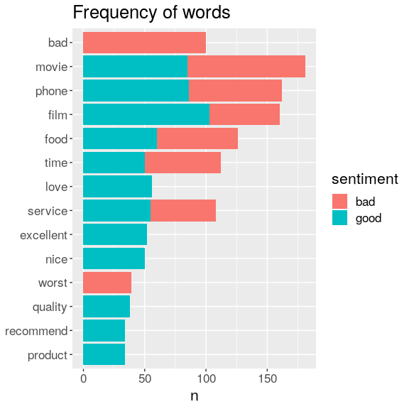

```r
words %>%
  count(word, sentiment, sort = TRUE) %>%
  head(20) %>%
  mutate(word = reorder(word, n)) %>%
  ggplot(aes(word, n, fill = sentiment)) +
  geom_col() +
  # scale_fill_manual(
  #   values = wine_plot_colours
  # ) +
  xlab(NULL) +
  theme(text = element_text(size = 16)) +
  coord_flip() +
  ggtitle("Frequency of words")
```

There are no surprises here! “Bad” is universally bad and “love” is universally good. It’s comforting to see. We’ll note this and use these words in our unit tests.

I’m not sure what purpose word clouds serve, but they seem almost mandatory.

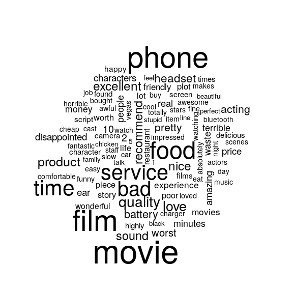

```r
words %>%
  count(word) %>%
  with(
    wordcloud::wordcloud(
      word,
      n,
      max.words = 100
    )
  )
```

# Preprocessing

We need to apply some preprocessing to our text before we can feed it into a model. The first round of preprocessing is simply ignoring case, punctuation and numbers:

```r
text_preprocessor
```

```
## function(x) {
##   x %>%
##     tolower %>%
##     tm::removeNumbers() %>%
##     tm::removePunctuation()
## }
## <environment: namespace:ModelAsAPackage>
```

I’m actually not sure that we *should* be removing numbers here. We’re dealing with reviews, after all, and a review like “10/10” certainly tells us something about sentiment. But that’s beyond the scope of this package.

The next round of processing involves tokenising our words. This is a process of stripping words down to their base. Another custom function, `stem_tokeniser` plays this role, by calling on the Porter stemming algorithm:

```r
stem_tokeniser("information informed informing informs")
```

```
## [[1]]
## [1] "inform" "inform" "inform" "inform"
```

Now we’ll define our vocabulary. The vocabulary is the domain of the problem — the words that will go into the model as features. Dimensionality is an issue here, we’’ll prune our vocabulary to include only words that occur a minimum number of times. The vocabulary is subject to *domain shift* — if an incoming piece of text contains a word that isn’t in the vocabulary, it will be ignored by the model.

We’re going to insist that every word in the vocabulary appears in at least 25 of the reviews.

```r
vocabulary <- create_vocabulary(reviews$review,
                                doc_proportion_min = 25 / nrow(reviews))
vocabulary
```

```
## Number of docs: 3000
## 1149 stopwords: a, a's, able, about, above, according ...
## ngram_min = 1; ngram_max = 1
## Vocabulary:
##           term term_count doc_count
##  1:        fit         25        25
##  2:        buy         25        25
##  3:       cast         25        25
##  4:      happi         25        25
##  5:    impress         25        25
##  6:    perform         25        25
##  7:     expect         26        26
##  8:       plot         27        26
##  9:        eat         27        27
## 10:        day         27        27
```

[output cut: 69 more lines]

Finally, we’ll create a vectoriser using the `text2vec` package. This allows us to map new text onto the vocabulary we’ve just created.

Actually, much of what you see here uses the `text2vec` package. I’m fond of this package because it’s designed with the idea that you may need to score new data that comes in after you’ve trained your model, so always need to be able to process new text!

```r
vectoriser <- vocabulary %>% text2vec::vocab_vectorizer()
```

One quick note, though: the `itoken` function in this package creates an iterator of tokens. It can be called like this:

```r
tokens <- text2vec::itoken(
  unprocessed_text,
  preprocessor = text_preprocessor,
  tokenizer = stem_tokeniser,
  progressbar = FALSE
)
```

However, I had great trouble with this method, with words not being properly tokenised before making it into the vectoriser. So I’ve done this instead:

```r
processed_text <- stem_tokeniser(text_preprocessor(unprocessed_text))

text2vec::itoken(
  processed_text,
  progressbar = FALSE
)
```

I would have thought that the two pieces of code were equivalent, but my unit tests fail with the first example. I’m putting this here as an unknown!

Creating a document term matrix

The input for our model algorithm is a *document term matrix*. This is a matrix in which every row represents one of our 3000 reviews, and every column uses one of the 78 terms in our vocabulary. We use the `map_to_dtm` function which allows us to map raw text onto a new dtm.

```r
map_to_dtm
```

```
## function(x,
##                        vectoriser = ModelAsAPackage::vectoriser,
##                        tfidf = ModelAsAPackage::tfidf) {
##   processed_text <- stem_tokeniser(text_preprocessor(x))
##
##   # For some reason, the preprocessor and stem_tokeniser don't take effect if
##   # I put them in the itoken function as values to the relevant arguments.
##   # Please let me know if you understand why this is!
##   tokens <- text2vec::itoken(
##     processed_text,
##     progressbar = FALSE
##   )
##
##   # If the input contains no terms corresponding the to vocabulary used to
##   # generate the vectoriser, then a warning will occur for an empty dtm.
##   # Since this is a plausible scenario, we suppress the warning.
##   suppressWarnings(
##     dtm <- text2vec::create_dtm(tokens, vectoriser)
##   )
##
##   if (!is.null(tfidf)) {
##     dtm <- tfidf$transform(dtm)
##   }
##
##   return(dtm)
## }
## <environment: namespace:ModelAsAPackage>
```

You’ll notice that `tfidf` argument. This stands for *term frequency inverse document frequency*. Informally, we want to weight every word as more important if it occurs often, and less important if it occurs in many documents. This is exactly what `tfidf` does. Let’s start with an unweighted matrix so we can see the effect.

```r
dtm_unweighted <- map_to_dtm(reviews$review,
                             vectoriser = vectoriser,
                             tfidf = NULL)
```

```r
paste0('> ', reviews$review[3000]) %>% cat
```

> Then, as if I hadn’t wasted enough of my life there, they poured salt in the wound by drawing out the time it took to bring the check.

```r
tail(as.matrix(dtm_unweighted)[3000,], 21)
```

```
##         im      excel     becaus    charact        ive    product
##          0          0          0          0          0          0
## disappoint  recommend    qualiti       onli       dont       love
##          0          0          0          0          0          0
##        bad     realli     servic       food       time      phone
##          0          0          0          0          1          0
##       film       movi       veri
##          0          0          0
```

Now we fit our `tfidf`. Be careful here: `fit_transform` is a method which says “use this data to define the `tfidf`, and then transform the input by that `tfidf`. This is distinct from `transform` which says”use a `tfidf` that’s already been fitted to transform this data". This terminology is more familiar to Python users than it is to R users, and I occasionally see it tripping people up (especially on Kaggle). The rule of thumb is that you use `fit_transform` for your training data and `transform` for your test data, or any new data that you encounter.

```r
tfidf <- text2vec::TfIdf$new()
dtm_tf_idf <- tfidf$fit_transform(dtm_unweighted)
```

Let’s take the same example before, but now with a weighted document term matrix:

```r
tail(as.matrix(dtm_tf_idf)[3000,], 21)
```

```
##         im      excel     becaus    charact        ive    product
##   0.000000   0.000000   0.000000   0.000000   0.000000   0.000000
## disappoint  recommend    qualiti       onli       dont       love
##   0.000000   0.000000   0.000000   0.000000   0.000000   0.000000
##        bad     realli     servic       food       time      phone
##   0.000000   0.000000   0.000000   0.000000   1.550546   0.000000
##       film       movi       veri
##   0.000000   0.000000   0.000000
```

# Training a random forest

With all of the effort we put into preprocessing, the model training step is relatively straightforward! Document term matrices are stored as a special class of *sparse* matrix, because there are computational techniques to efficiently store and use matrices in which the vast majority of entries are 0. However, this format isn’t accepted by the `randomForest` algorithm. Fortunately, with only 3000 rows and 78 columns, we don’t have to worry too much about computational efficiency.

```r
review_rf <- randomForest::randomForest(
  x = as.matrix(dtm_tf_idf),
  y = factor(reviews$sentiment),
  ntree = 500
)
```

While I don’t want to invest much time in the model itself, we can at least look at how it performs, and which terms it considers the most important:

```r
review_rf
```

```
##
## Call:
##  randomForest(x = as.matrix(dtm_tf_idf), y = factor(reviews$sentiment),      ntree = 500)
##                Type of random forest: classification
##                      Number of trees: 500
## No. of variables tried at each split: 8
##
##         OOB estimate of  error rate: 33.7%
## Confusion matrix:
##       bad good class.error
## bad  1167  333       0.222
## good  678  822       0.452
```

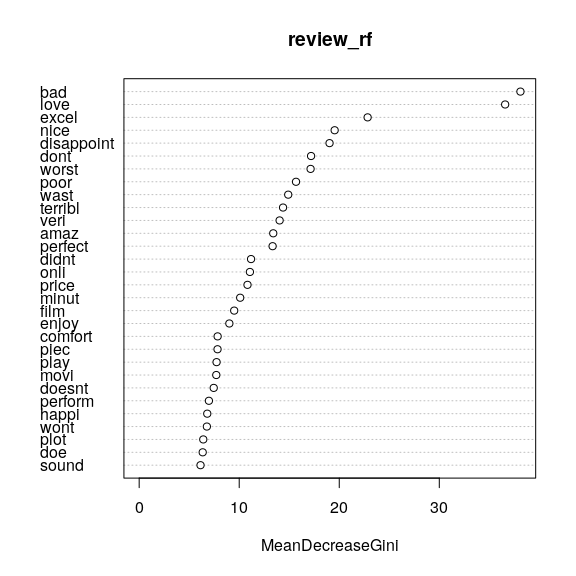

```r
randomForest::varImpPlot(review_rf)
```

# Artefact output

Now we recall that we’re actually creating a package. We want all of the work that we’ve done so far to be included in the final result. Fortunately, our custom functions are in the `R` directory, so they’ll persist when the package is compiled. We need three other objects (all relating to our trained model) to be available as well: our random forest `review_rf`, our `vectoriser`, and the `tfidf` we used to weight our training data (and will reuse for new data). These are all (sparsely) documented with their own entries in the `R` directory.

```r
usethis::use_data(review_rf,
                  vectoriser,
                  tfidf,
                  pkg = package_root,
                  overwrite = TRUE)
```